# Assignment_8_Everitt.Amanda

**Student Name:** Amanda Everitt

**Student ID:** 998974934

Q1: Can you see any obvious differences by eye?

> Just by eye, it appears that the intron.9.fa and intron.7.fa file has shorter sequences than the intron.1.fa. This would make sense because the size of the files progessively decrease, intron 1 being 7.3M larger than intron 9. Also, all the files appear to be very A/T heavy.

```
for i in `seq 1 9` ; do perl kmer_stats.pl -k 1 introns.$i.fa ; done
```

Q2: Do the compositions of introns at different locations look different by mono-nucleotide composition?

> Yes, looking at the mono nucleotide frequencies make the intron composition noticeably different. For example the freq(A) at intron 1,2 and 3 is 0.274 whereas it is only 0.26 at intron 6,7,8,and 9.The freq(A) decreases as you move downstream. It also appears that freq(G) increases as you move from intron 1 to intron 9. While there are differences it is very difficult to determine if they are significant.

```
for i in `seq 1 9`; do perl ./kmer_stats.pl -k 5 introns.$i.fa > counts.$i.5.txt ; done
paste counts.1.5.txt counts.2.5.txt
paste counts.2.5.txt counts.6.5.txt

paste counts.1.5.txt counts.2.5.txt | awk '{print $2, $5, $1}'| sort -n > newfile.1.2.txt
paste counts.1.5.txt counts.9.5.txt | awk '{print $2, $5, $1}'| sort -n > newfile.1.9.txt
```

Q3: Do you see any obvious differences? Do you think these are statistically relevant or just random noise? How could you tell the difference?

```
OUPUT:

intron 1              intron 2
0.000102545621274306 0.000108914573164916 GCGGT
0.000101254579279846 6.88475540213461e-05 CGACC
intron 1              intron 9
0.000102545621274306 9.62051541351996e-05 GCGGT
0.000101254579279846 6.04078874802416e-05 CCGAC
```

```
sh loop_kl.sh > KLdist.txt
awk '{print $4, $1,$2,$3}' KLdist.txt | sort
```

Q4: Which introns are similar and different from others? Are first introns different from introns farther downstream as suggested by the biological model of IME?

```
OUTPUT:

These are the top 5, most similar introns (not including self vs self):
0.00247028874764407 4 vs 5:
0.00259928992974639 3 vs 4:
0.0026265499212776  5 vs 6:
0.00292964265062677 6 vs 7:
0.003381872209034   4 vs 6:

These are the last 5, most dissimilar introns:
0.0332441443647111 5 vs 1:
0.0365920029496328 8 vs 1:
0.0370553786851746 6 vs 1:
0.0374644263349917 9 vs 1:
0.0379317501778011 7 vs 1:
```

```
for k in `seq 1 9`; do perl kmer_stats.pl -k $k proximal.fa > counts.proximal.$k.txt; perl kmer_stats.pl -k $k distal.fa   > counts.distal.$k.txt; echo -n "k=$k "; perl kl_distance.pl counts.proximal.$k.txt counts.distal.$k.txt; done
```

Q5: The program reported some errors at high values of K. Any idea why?

> With larger K values, there is less chance that the same 7nt sequence occurs in each file. It is essentially 4,096 (4^6) possibilities versus 16,384 (4^7) possibilites. This is why at large K values you will commonly get counts of zero which is why the program reprots errors.

```
for i in `seq 1 9`; do perl discriminator.pl counts.proximal.$i.txt counts.distal.$i.txt proximal.fa  > prox.$i.txt ; done

cat prox.* > prox.all.txt

for i in `seq 1 9`; do perl discriminator.pl counts.proximal.$i.txt counts.distal.$i.txt distal.fa  > dist.$i.txt ; done

cat dist.* > dist.all.txt

awk '{print $2}' prox.all.txt |  awk '{x+=$0}END{print x}'
#251590

wc -l prox.all.txt
#167166 prox.all.txt

awk '{print $2}' dist.all.txt |  awk '{x+=$0}END{print x}'
#-223692

wc -l dist.all.txt
#210564 dist.all.txt
```

Q6: What is the average score of a proximal intron? What is the average score of a distal intron? Use R to plot histograms.

> The average score of a proximal intron is 1.505 (251590/167166). The average score of a distal intron is -1.06 (-223692/210564).

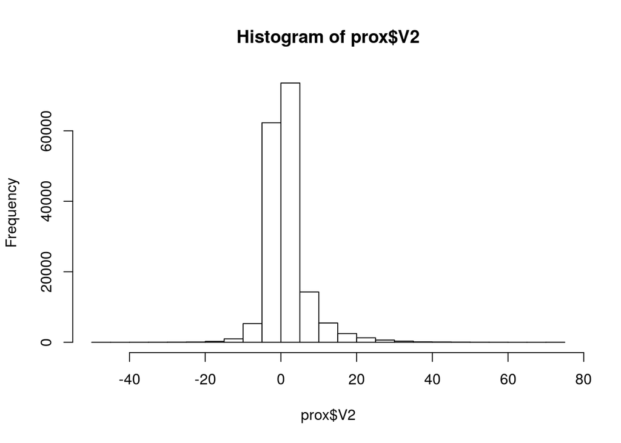

```r
setwd("~/MEGA/BIS180L/Labwork/Github/Assignment_8_Everitt.Amanda/imelab")
prox <- read.delim("prox.all.txt", header=FALSE)
dist <- read.delim("dist.all.txt", header=FALSE)
hist(prox$V2)
```

[figure not shown]

[output not shown]

```r
hist(dist$V2)
```

Q7: What values of K work well? Why do you think that is? How does data set size influence the optimal value of K?

k=1 : 0.1875412 k=2 : 0.3765344 k=3 : 0.4921342 k=4 : 0.5179208 k=5 : 0.5078738 k=6 : 0.523392

> The larger the data set, the higher the optimal K value because there is a greater chance that the a sequence length K will actually occur.

```
cat introns.*.fa > all_introns.fa
perl discriminator.pl counts.proximal.5.txt counts.distal.5.txt all_introns.fa | sort -n -k2
```

Q8: Which intron in A. thaliana is predicted to enhance expression the most?

> IME_Athaliana_77647 is the intron with the highest predicted value of 62.65. This is preliminarily the intron most likely to enhance expression the most.